# 01 - Analysis 1

Selin Jessa

23 May, 2020

# 1 Configuration

Configuration of project directory & analysis outputs:

**Show full config**

```r
library(here)
```

```r
# Set up outputs

# ...determines the name of the cache folder
project_id <- "rr"

# ...determines name of the subfolder of `outputs` and `figures`
doc_id     <- "01"

# ...specify where to save outputs
out        <- here("output", doc_id); dir.create(out, recursive = TRUE)
figout     <- here("figures", doc_id, "/")
cache      <- paste0("~/tmp/", project_id, "/", doc_id, "/")
```

The root directory of this project is:

```
## /Users/selinjessa/Repos/rr
```

Outputs and figures will be saved at these paths, relative to project root:

```
## rr/output/01
```

```
## rr/figures/01//
```

# 2 Overview

This is an example of the first analysis in a project.

# 3 Libraries

```r
library(ggplot2)
library(tidyverse)
```

Here is a note to self. This markdown code is contained in a check, with visibility controlled by the `echo` chunk option.

Change echo to TRUE or FALSE to display/hide this chunk.

# 4 Analysis

## 4.1 Part 1

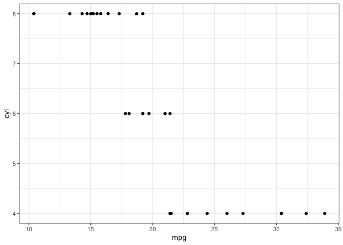

```r
mtcars %>%
    ggplot(aes(x = mpg, y = cyl)) +
    geom_point() +
    theme_bw()
```

## 4.2 Part 2

This part of the analysis saves the `mtcars` dataset from R as a TSV. By matching the chunk name to the output file name, we can then use the `echo_out = TRUE` chunk option to show the path to the fil.

```r
head(mtcars)
```

|  | mpg | cyl | disp | hp | drat | wt | qsec | vs | am | gear | carb |
| --- | --- | --- | --- | --- | --- | --- | --- | --- | --- | --- | --- |
| Mazda RX4 | 21.0 | 6 | 160 | 110 | 3.90 | 2.620 | 16.46 | 0 | 1 | 4 | 4 |
| Mazda RX4 Wag | 21.0 | 6 | 160 | 110 | 3.90 | 2.875 | 17.02 | 0 | 1 | 4 | 4 |
| Datsun 710 | 22.8 | 4 | 108 | 93 | 3.85 | 2.320 | 18.61 | 1 | 1 | 4 | 1 |
| Hornet 4 Drive | 21.4 | 6 | 258 | 110 | 3.08 | 3.215 | 19.44 | 1 | 0 | 3 | 1 |
| Hornet Sportabout | 18.7 | 8 | 360 | 175 | 3.15 | 3.440 | 17.02 | 0 | 0 | 3 | 2 |
| Valiant | 18.1 | 6 | 225 | 105 | 2.76 | 3.460 | 20.22 | 1 | 0 | 3 | 1 |

```r
write.table(mtcars, file.path(out, "mtcars.tsv"))
```

<sub>[output @ *rr/output/01/mtcars.tsv*]</sub>

# 5 Reproducibility

This document was last rendered on:

```
## 2020-05-23 20:06:02
```

[figure not shown]

A project of the Kleinman Lab at McGill University.